# Code: Demand Estimation with Machine Learning

Georgi Zhelev

The code is presented and explained. Outputs are shown where appropriate. To save space and maintain clarity, selected results are shown at the end. For further details please see the executable r-data file, which is provided with the data storage device.

# Model Assumptions

The first section of the code represents the model assumptions.

## Model Characteristics

This line of code determines the number of cross-validation folds and could be changed to increase computational speed. The results were generated with 5 folds, which amounted to 2 minutes of run time. Cross-Validation is used for the tuning of ML-Methods.

```r
cv.folds<-5
```

The model assumptions are 10, 50, 150 and 290 features, *p*. The number of observations *n* is kept constant at 300. The parameter *cvfolds* was already assigned to 5.

```r
p<-c(10, 50, 150, 290)
n=300
cvfolds <- cv.folds
```

## Labels

Next, the names of the four runs and alternatives are set up, which will later be used to label the rows and columns of the results-data-frames.

```r
name<-c(p[1], p[2], p[3], p[4])
names<-c("p=", "p=", "p=", "p=")
index<-paste(names, name, sep = "", collapse = NULL)
alt.names <- c("TF", "HB", "NC")
run.names <- c("run1", "run2","run3", "run4")
```

## Create Storage for Loop Results

Storage data frames in the form of lists are created for the storage of results such as signal-to-noise ratios, accuracies, coefficients, confusion matrices, variable importance and tabulations of the y-variable.

```r
details <- list()
coeff.logit <- list()
details1 <- list()
details3 <- list()
details4 <- list()

coeff.reg <- list()
coeff.reg.TF<- list()
coeff.reg.HB<- list()
coeff.reg.NC<- list()

coeff.lasso <- list()
coeff.lasso.TF <- list()
coeff.lasso.HB <- list()
coeff.lasso.NC <- list()

cm.logit <- list()
cm.reg <- list()
cm.lasso <- list()
cm.tree <- list()
cm.rf <- list()
cm.boost <- list()

rf_plot <- list()
gbm_plot <- list()

summ_fit_sample <- list()
summ_test_sample <- list()
summ_fit_lin_sample <- list()
summ_test_lin_sample <- list()
```

## Loop

Finally a for-loop is created to vary based on the assigned *p*’s.

```r
for (i in 1:length(p)) {
  p[i]<-p[i]
```

# Simulation

## Set Relevant Coefficients

Next the relevant coefficients are set to -5, 3 and 5. A vector *sparce* is created to count the number of non-relevant features. In the case of the first run *p=10*, which will serve as an example, are the non-relevant coefficients 7.

```r
pr<--5    #price
qual<-3 #quanlity
pop<-5  #popularity
sparce<-p-(length(pr)+length(qual)+length(pop)) #count 0-betas for sparcity
sparce
```

```
## [1] 7
```

Then a beta vector is created with the 3 relevant coefficients, while the rest are set to 0.

```r
set.seed(1)
beta2<- c(pr, qual, pop, rep(0, sparce))
beta2
```

```
##  [1] -5  3  5  0  0  0  0  0  0  0
```

## Generate X-Variables

In the next step the price, quality and popularity averages are assigned to the three alternatives (TF, HB and NC). The alternatives are modeled to be dissimilar, therefore each has a different magnitude of price, quality and popularity. Below are the coefficient-means of the first alternative shown.

```r
prices<-c(3.90, 3.50, 1.50)

mu1=c(rep(prices[1] , length(pr)), rep(5 , length(qual)), rep(2 , length(pop)),
      rep(0, sparce)) #TF

mu2=c(rep(prices[2] , length(pr)), rep(1 , length(qual)), rep(4 , length(pop)),
      rep(0, sparce)) #HB
mu3=c(rep(prices[3] , length(pr)), rep(1 , length(qual)), rep(2 , length(pop)),
      rep(0, sparce)) #NC

round(mu1, 1)
```

```
##  [1] 3.9 5.0 2.0 0.0 0.0 0.0 0.0 0.0 0.0 0.0
```

Next the covariance structure of the *x*’s is created, which is based on a diagonal matrix. Therefore the *x*’s are not dependent on each other.

```r
set.seed(1)
covar=diag(0.2, p, p)
head(covar)
```

```
##      [,1] [,2] [,3] [,4] [,5] [,6] [,7] [,8] [,9] [,10]
## [1,]  0.2  0.0  0.0  0.0  0.0  0.0    0    0    0     0
## [2,]  0.0  0.2  0.0  0.0  0.0  0.0    0    0    0     0
## [3,]  0.0  0.0  0.2  0.0  0.0  0.0    0    0    0     0
## [4,]  0.0  0.0  0.0  0.2  0.0  0.0    0    0    0     0
## [5,]  0.0  0.0  0.0  0.0  0.2  0.0    0    0    0     0
## [6,]  0.0  0.0  0.0  0.0  0.0  0.2    0    0    0     0
```

After that the *x*’s are created using the covariance structure and the means.

```r
X1=rmvnorm(n, mean=mu1, sigma=covar)
X2=rmvnorm(n, mean=mu2, sigma=covar)
X3=rmvnorm(n, mean=mu3, sigma=covar)
str(X1)
```

```
##  num [1:300, 1:10] 3.62 4.58 4.31 4.51 3.83 ...
```

The created X-matrices are 300 observations long and 10 observations wide.

Finally the *x*’s are packed into a matrix for each alternative and are labeled.

```r
x1<-matrix(X1, nrow = n, ncol = p)
colnames(x1)<-paste(as.character(1:p), rep(".TF", p), sep = "")
x2<-matrix(X2, nrow = n, ncol = p)
colnames(x2)<-paste(as.character(1:p), rep(".HB", p), sep = "")
x3<-matrix(X3, nrow = n, ncol = p)
colnames(x3)<-paste(as.character(1:p), rep(".NC", p), sep = "")
```

## Calculate Utility

To obtain representative utility, matrix multiplication is done and the X-matrices are transposed.

```r
V1<-beta2%*%t(x1)    #1st product
V2<-beta2%*%t(x2)    #2nd product
V3<-beta2%*%t(x3)    #3rd product
```

The resulting representative utilities are bound into a single matrix.

```r
V<-cbind(t(V1), t(V2), t(V3))
summary(V)
```

```
##        V1               V2               V3
##  Min.   :-6.176   Min.   :-3.674   Min.   :-3.395
##  1st Qu.: 3.288   1st Qu.: 3.197   1st Qu.: 3.805
##  Median : 5.508   Median : 6.087   Median : 5.802
##  Mean   : 5.759   Mean   : 5.718   Mean   : 5.749
##  3rd Qu.: 8.054   3rd Qu.: 7.852   3rd Qu.: 7.943
##  Max.   :15.053   Max.   :16.076   Max.   :13.755
```

```r
str(V)
```

```
##  num [1:300, 1:3] 5.28 1.25 4.66 3.19 7.09 ...
```

## Generate Error Term

Next, the error term is generated using the package for generating extreme values.

```r
#install.packages("evd")
library(evd)
set.seed(1)
e1<-rgumbel(n*ncol(V), loc=0, scale=1.72)
e1<-matrix(e1,n,ncol(V),byrow=FALSE)
str(e1)
```

```
##  num [1:300, 1:3] 0.483 -0.287 3.313 3.384 1.428 ...
```

The model is completed by adding the unobserved (random) values of utility.

```r
z1<-V+e1
```

## Investigate Signal-to-Noise Ratio

```r
signal<-mean(var(V))
noise<-mean(var(e1))
noise
```

```
## [1] 1.64465
```

The noise is according to logit-model assumptions.

```r
snr<-mean(var(V))/mean(var(e1))
snr
```

```
## [1] 2.236826
```

The signal-to-noise is above 2.

## Calculate Logit Probabilities

```r
pr1 = exp(z1)/apply(exp(z1), drop=F, 1, sum)
```

The probabilities have the necessary qualities. They are between 0 and 1.

```r
specify_decimal <- function(x, k) trimws(format(round(x, k), nsmall=k))
head(specify_decimal(pr1, 2))
```

```
##      [,1]   [,2]   [,3]
## [1,] "0.05" "0.95" "0.00"
## [2,] "0.01" "0.00" "0.98"
## [3,] "0.23" "0.32" "0.45"
## [4,] "0.40" "0.00" "0.60"
## [5,] "0.95" "0.05" "0.00"
## [6,] "0.00" "0.96" "0.04"
```

They sum to 1.

```r
head(apply(pr1, drop=F, 1, sum))
```

```
## [1] 1 1 1 1 1 1
```

Next using the *apply* command, the *rmultinom* function is applied on in the previous step generated probability matrix. One random vector is drawn for each row of the probability matrix. Using the generated probabilities one object is chosen. As seen in the output, where the probability is highest, is the chance higher for that column to take on the value of 1.

```r
mChoices1 = t(apply(pr1, 1, rmultinom, n = 1, size = 1))
head(mChoices1)
```

```
##      [,1] [,2] [,3]
## [1,]    0    1    0
## [2,]    0    0    1
## [3,]    0    1    0
## [4,]    0    0    1
## [5,]    1    0    0
## [6,]    0    1    0
```

## Generate Y-Variable

By replacing 1-s with respective column labels, a categorical ranking results with the options *y=1,2 or 3*.

```r
y1 = apply(mChoices1, 1, function(x) which(x==1))
head(y1)
```

```
## [1] 2 3 2 3 1 2
```

```r
length(y1)
```

```
## [1] 300
```

```r
tabulate(y1)
```

```
## [1] 103 109  88
```

## Safe Data

A data frame for not linear Methods: logit, tree, random forest and boosting is saved.

```r
cereals<-data.frame(y1,x1,x2,x3)
str(cereals)
```

```
## 'data.frame':    300 obs. of  31 variables:
##  $ y1    : int  2 3 2 3 1 2 2 3 1 1 ...
##  $ X1.TF : num  3.62 4.58 4.31 4.51 3.83 ...
##  $ X2.TF : num  5.08 5.17 5.35 4.95 4.89 ...
##  $ X3.TF : num  1.63 1.72 2.03 2.17 2.31 ...
##  $ X4.TF : num  0.7134 -0.9904 -0.8897 -0.0241 0.2489 ...
##  $ X5.TF : num  0.147 0.503 0.277 -0.616 -0.308 ...
##  $ X6.TF : num  -0.3669 -0.0201 -0.0251 -0.1856 -0.3164 ...
##  $ X7.TF : num  0.21798 -0.00724 -0.06967 -0.17633 0.16305 ...
##  $ X8.TF : num  0.3302 0.4221 -0.6577 -0.0265 0.3437 ...
##  $ X9.TF : num  0.2575 0.3673 -0.2138 0.4919 -0.0502 ...
##  $ X10.TF: num  -0.137 0.266 0.187 0.341 0.394 ...
##  $ X1.HB : num  3.83 3.72 3.52 4.1 3.7 ...
##  $ X2.HB : num  1.173 1.192 1.69 0.206 0.804 ...
##  $ X3.HB : num  4.58 3.43 4.43 4.17 4.54 ...
```

[output cut: 17 more lines]

for linear Methods: regression and lasso, a second data frame is saved. The second data frame is the same as the first, except for that it has three additional probability variables (X1, X2 and X3).

```r
cereals.lin<-data.frame(y1,pr1,x1,x2,x3)
names(cereals.lin)
```

```
##  [1] "y1"     "X1"     "X2"     "X3"     "X1.TF"  "X2.TF"  "X3.TF"
##  [8] "X4.TF"  "X5.TF"  "X6.TF"  "X7.TF"  "X8.TF"  "X9.TF"  "X10.TF"
## [15] "X1.HB"  "X2.HB"  "X3.HB"  "X4.HB"  "X5.HB"  "X6.HB"  "X7.HB"
## [22] "X8.HB"  "X9.HB"  "X10.HB" "X1.NC"  "X2.NC"  "X3.NC"  "X4.NC"
## [29] "X5.NC"  "X6.NC"  "X7.NC"  "X8.NC"  "X9.NC"  "X10.NC"
```

## Assign Levels

Format the y-column in the data frame as a factor and call it “choice”.

```r
choice<-factor(cereals$y1)
head(choice)
```

```
## [1] 2 3 2 3 1 2
## Levels: 1 2 3
```

Name the levels of the as-factor-formatted choice-column. 1 for Tiger Flakes (TF), 2 for Honey Bits (HB) and 3 for Nougat Crisps (NC).

```r
levels<-c("TF", "HB", "NC")
levels(choice)<-levels
head(choice)
```

```
## [1] HB NC HB NC TF HB
## Levels: TF HB NC
```

Replace the “y” column with the “choice” column in the data frames.

```r
cereals<-cbind(choice, cereals[,-1])
cereals.lin<-cbind(choice, cereals.lin[,-1])
```

# Model Fitting and Tuning

The fitting of the six classical and machine learning models is presented next.

## Fit Logit

### Split Data

Find split point in the data.

```r
r<-nrow(cereals)/2
r
```

```
## [1] 150
```

```r
cereals_fit<-cereals[1:r,]
cereals_test<-cereals[-(1:r),]
nrow(cereals_fit)
```

```
## [1] 150
```

#### Means of Samples

```r
round(sapply(cereals_fit[,-1], mean), 2)
```

```
##  X1.TF  X2.TF  X3.TF  X4.TF  X5.TF  X6.TF  X7.TF  X8.TF  X9.TF X10.TF
##   3.86   5.08   2.01  -0.07   0.06  -0.03  -0.02  -0.03  -0.03   0.03
##  X1.HB  X2.HB  X3.HB  X4.HB  X5.HB  X6.HB  X7.HB  X8.HB  X9.HB X10.HB
##   3.49   1.00   4.05   0.00   0.01  -0.02  -0.02   0.08  -0.01  -0.05
##  X1.NC  X2.NC  X3.NC  X4.NC  X5.NC  X6.NC  X7.NC  X8.NC  X9.NC X10.NC
##   1.46   1.07   1.94  -0.02  -0.06  -0.02  -0.01   0.00   0.09  -0.01
```

Below is a tabulation of the selected alternatives in the train sample.

```r
summ_cereals_fit<-summary(cereals_fit$choice)
summ_cereals_fit
```

```
## TF HB NC
## 51 57 42
```

```r
summ_cereals_test<-summary(cereals_test$choice)
```

### Transform Data into Mlogit Data Object

```r
library(mlogit)
Cereal_fit <- mlogit.data(cereals_fit, varying = c(2:ncol(cereals_fit)),
                          shape = "wide", choice = "choice")
Cereal_test <- mlogit.data(cereals_test, varying = c(2:ncol(cereals_test)),
                           shape = "wide", choice = "choice")
```

### Set up Flexible Formula for Logit

```r
last<-ncol(Cereal_fit)-2
k<-colnames(Cereal_fit)[-1]
k<-k[-1]
k<-k[-last]
factors <- k
factors
```

```
##  [1] "X1"  "X2"  "X3"  "X4"  "X5"  "X6"  "X7"  "X8"  "X9"  "X10"
```

```r
X<-as.formula(paste("choice~", paste(factors, collapse="+")))
X
```

```
## choice ~ X1 + X2 + X3 + X4 + X5 + X6 + X7 + X8 + X9 + X10
```

```r
f1 <- mFormula(X)
```

### Remove Intercept

```r
f0 <- update(f1, .~.-1)
```

### Fit Logit Model

```r
m<-mlogit(f0, data=Cereal_fit, seed = 1)
```

### In-Sample Performance

Make predictions. The logit predictions are in the form of probabilities.

```r
library("caret")
set.seed(1)
logit.pred_in<-fitted(m, outcome = FALSE)
head(logit.pred_in)
```

```
##           HB         NC          TF
## 1 0.80802081 0.00895389 0.183025301
## 2 0.15875477 0.71489982 0.126345407
## 3 0.95266582 0.01520610 0.032128083
## 4 0.03575981 0.85312309 0.111117101
## 5 0.36271514 0.01108054 0.626204322
## 6 0.70555287 0.29111293 0.003334203
```

The column names are used to label the alternatives.

```r
y_hat = colnames(logit.pred_in)[apply(logit.pred_in, 1, which.max)]
head(y_hat)
```

```
## [1] "HB" "NC" "HB" "NC" "TF" "HB"
```

They are then compared to the observed alternatives from the train sample.

```r
logit_in = confusionMatrix(cereals_fit$choice, as.factor(y_hat))
```

The accuracy is recorded the generated confusion matrix output.

```r
logit_in[2]
```

```
## $table
##           Reference
## Prediction HB NC TF
##         HB 41  6 10
##         NC  9 31  2
##         TF  6  3 42
```

```r
logit_in<-logit_in$overall[1]*100
logit_in
```

```
## Accuracy
##       76
```

```r
logit_in<-logit_in[[1]]
logit_in
```

```
## [1] 76
```

### Out-of-Sample Performance

Make predictions

```r
logit.pred_out<-predict(m, newdata=Cereal_test)
```

#### Data-Check

Specify a decimal format for the predicted probabilities and reformat the predicted probabilities into a readable format.

```r
specify_decimal <- function(x, k) trimws(format(round(x, k), nsmall=k))
head(specify_decimal(logit.pred_out, 2))
```

```
##   HB     NC     TF
## 1 "0.01" "0.62" "0.38"
## 2 "0.02" "0.43" "0.55"
## 3 "0.00" "0.00" "1.00"
## 4 "0.87" "0.11" "0.02"
## 5 "0.04" "0.89" "0.06"
## 6 "0.26" "0.03" "0.71"
```

Verify predicted probabilities add to 1

```r
head(apply(logit.pred_out, drop=F, 1, sum))
```

```
## 1 2 3 4 5 6
## 1 1 1 1 1 1
```

Record accuracy.

```r
y_hat = colnames(logit.pred_out)[apply(logit.pred_out, 1, which.max)]
head(y_hat)
```

```
## [1] "NC" "TF" "TF" "HB" "NC" "TF"
```

```r
logit_out_cm = confusionMatrix(as.factor(y_hat), cereals_test$choice)
logit_out<-logit_out_cm$overall[1]*100
logit_out<-logit_out[[1]]
```

### Save Results

```r
logit<-round(cbind(logit_in, logit_out), 0)
logit
```

```
##      logit_in logit_out
## [1,]       76        78
```

## Fit Linear Regression

### Split Data

find split point in the data and split it.

```r
r<-nrow(cereals.lin)/2
cereals_fit<-cereals.lin[1:r,]
cereals_test<-cereals.lin[-(1:r),]
names(cereals_fit)
```

```
##  [1] "choice" "X1"     "X2"     "X3"     "X1.TF"  "X2.TF"  "X3.TF"
##  [8] "X4.TF"  "X5.TF"  "X6.TF"  "X7.TF"  "X8.TF"  "X9.TF"  "X10.TF"
## [15] "X1.HB"  "X2.HB"  "X3.HB"  "X4.HB"  "X5.HB"  "X6.HB"  "X7.HB"
## [22] "X8.HB"  "X9.HB"  "X10.HB" "X1.NC"  "X2.NC"  "X3.NC"  "X4.NC"
## [29] "X5.NC"  "X6.NC"  "X7.NC"  "X8.NC"  "X9.NC"  "X10.NC"
```

Test sample includes logit probabilities.

record summary statistics of samples for later

```r
summ_cereals_fit_lin<-summary(cereals_fit$choice)
summ_cereals_test_lin<-summary(cereals_test$choice)
```

### Pre-Process Data

#### Separate Data for Regressions

Data frames are build using the logit probability and features per alternative.

```r
cereals.TF<-cbind(cereals_fit$X1, cereals_fit[(1+4):(5+p-1)])
str(cereals.TF)
```

```
## 'data.frame':    150 obs. of  11 variables:
##  $ cereals_fit$X1: num  0.0477 0.0122 0.2296 0.4004 0.9462 ...
##  $ X1.TF         : num  3.62 4.58 4.31 4.51 3.83 ...
##  $ X2.TF         : num  5.08 5.17 5.35 4.95 4.89 ...
##  $ X3.TF         : num  1.63 1.72 2.03 2.17 2.31 ...
##  $ X4.TF         : num  0.7134 -0.9904 -0.8897 -0.0241 0.2489 ...
##  $ X5.TF         : num  0.147 0.503 0.277 -0.616 -0.308 ...
##  $ X6.TF         : num  -0.3669 -0.0201 -0.0251 -0.1856 -0.3164 ...
##  $ X7.TF         : num  0.21798 -0.00724 -0.06967 -0.17633 0.16305 ...
##  $ X8.TF         : num  0.3302 0.4221 -0.6577 -0.0265 0.3437 ...
##  $ X9.TF         : num  0.2575 0.3673 -0.2138 0.4919 -0.0502 ...
##  $ X10.TF        : num  -0.137 0.266 0.187 0.341 0.394 ...
```

```r
cereals.HB<-cbind(cereals_fit$X2, cereals_fit[(5+p-1+1):(5+2*p-1)])
cereals.NC<-cbind(cereals_fit$X3, cereals_fit[(5+2*p-1+1):ncol(cereals_fit)])
```

Test Data has the same structure as the train data.

```r
cereals.TF.test<-cbind(cereals_test$X1, cereals_test[(1+4):(5+p-1)])
cereals.HB.test<-cbind(cereals_test$X2, cereals_test[(5+p-1+1):(5+2*p-1)])
cereals.NC.test<-cbind(cereals_test$X3, cereals_test[(5+2*p-1+1):ncol(cereals_fit)])
```

### Set up Formulas for 3 Regressions

```r
k<-colnames(cereals.TF[2:ncol(cereals.TF)])
TF<-as.formula(paste("log(cereals.TF[,1])~", paste(k, collapse="+")))
TF
```

```
## log(cereals.TF[, 1]) ~ X1.TF + X2.TF + X3.TF + X4.TF + X5.TF +
##     X6.TF + X7.TF + X8.TF + X9.TF + X10.TF
```

```r
k<-colnames(cereals.HB[2:ncol(cereals.HB)])
HB<-as.formula(paste("log(cereals.HB[,1])~", paste(k, collapse="+")))
HB
```

```
## log(cereals.HB[, 1]) ~ X1.HB + X2.HB + X3.HB + X4.HB + X5.HB +
##     X6.HB + X7.HB + X8.HB + X9.HB + X10.HB
```

```r
k<-colnames(cereals.NC[2:ncol(cereals.NC)])
NC<-as.formula(paste("log(cereals.NC[,1])~", paste(k, collapse="+")))
NC
```

```
## log(cereals.NC[, 1]) ~ X1.NC + X2.NC + X3.NC + X4.NC + X5.NC +
##     X6.NC + X7.NC + X8.NC + X9.NC + X10.NC
```

#### Remove Intercept

```r
form.TF <- update(TF, .~.-1)
form.HB <- update(HB, .~.-1)
form.NC <- update(NC, .~.-1)
```

### Fit Regression Models

```r
ols.TF <- lm(form.TF, data=cereals.TF)
ols.HB <- lm(form.HB, data=cereals.HB)
ols.NC <- lm(form.NC, data=cereals.NC)
```

### In-Sample Predictions

The predictions of the three regressions are compared.

```r
TF<-fitted(ols.TF, outcome = FALSE)
HB<-fitted(ols.HB, outcome = FALSE)
NC<-fitted(ols.NC, outcome = FALSE)
util<-cbind(TF, HB, NC)
head(util, 4)
```

```
##          TF        HB        NC
## 1 -2.848340 -2.811533 -4.560369
## 2 -5.846930 -5.872507 -2.778482
## 3 -5.301662 -2.086851 -4.101773
## 4 -5.686562 -6.390244 -2.695700
```

The alternative that has the highest utility is chosen.

```r
wahl<-apply(util, 1, function(x) which.max(x))
head(wahl)
```

```
## 1 2 3 4 5 6
## 2 3 2 3 1 2
```

Column numbers serve as indicators for the alternatives.

### In-Sample Correct

The predicted choices are compared to the numeric of the observed choices. The comparison is done in a confusion matrix.

```r
y_hat<-as.numeric(wahl)
cm = table(wahl, cereals_fit$choice)
cm
```

```
##
## wahl TF HB NC
##    1 40  7  3
##    2  6 44  9
##    3  5  6 30
```

Accuracy is calculated

```r
reg_in<-sum(diag(cm))/sum(cm)*100
reg_in
```

```
## [1] 76
```

### Out-of-Sample Predictions

Make Predictions.

```r
TF=predict(ols.TF, newdata =cereals.TF.test)
HB=predict(ols.HB, newdata =cereals.HB.test)
NC=predict(ols.NC, newdata =cereals.NC.test)
util<-cbind(TF, HB, NC)
```

### Out-of-Sample Correct

```r
wahl<-apply(util, 1, function(x) which.max(x))
reg_out_cm = table(wahl, cereals_test$choice)
rownames(reg_out_cm)<- alt.names
reg_out<-sum(diag(reg_out_cm))/sum(reg_out_cm)*100
```

### Store Results

```r
lin.reg<-round(cbind(reg_in, reg_out), 0)
lin.reg
```

```
##      reg_in reg_out
## [1,]     76      71
```

## Fit LASSO

LASSO using glmnet package requires coding the y and x variables in separate matrices.

### Code train and test samples for lasso.cv

#### Train

```r
Y.train.TF = log(cereals.TF[, 1]) # output variable
str(Y.train.TF)
```

```
##  num [1:150] -3.0428 -4.4063 -1.4714 -0.9153 -0.0553 ...
```

```r
X.train.TF = as.matrix(cereals.TF[,2:ncol(cereals.TF)]) # regressors
str(X.train.TF)
```

```
##  num [1:150, 1:10] 3.62 4.58 4.31 4.51 3.83 ...
##  - attr(*, "dimnames")=List of 2
##   ..$ : chr [1:150] "1" "2" "3" "4" ...
##   ..$ : chr [1:10] "X1.TF" "X2.TF" "X3.TF" "X4.TF" ...
```

```r
Y.train.HB = log(cereals.HB[, 1]) # output variable
X.train.HB = as.matrix(cereals.HB[,2:ncol(cereals.HB)]) # regressors
Y.train.NC = log(cereals.NC[, 1]) # output variable
X.train.NC = as.matrix(cereals.NC[,2:ncol(cereals.NC)]) # regressors
```

#### Test

```r
Y.test.TF = log(cereals.TF.test[, 1]) # output variable
X.test.TF = as.matrix(cereals.TF.test[,2:ncol(cereals.TF)]) # regressors
Y.test.HB = log(cereals.HB.test[, 1]) # output variable
X.test.HB = as.matrix(cereals.HB.test[,2:ncol(cereals.HB)]) # regressors
Y.test.NC = log(cereals.NC.test[, 1]) # output variable
X.test.NC = as.matrix(cereals.NC.test[,2:ncol(cereals.NC)]) # regressors
```

### Do Cross-Validation

```r
library(glmnet)
lasso.cv.TF=cv.glmnet(X.train.TF, Y.train.TF, family="gaussian",alpha=1)
lasso.cv.HB=cv.glmnet(X.train.HB, Y.train.HB, family="gaussian",alpha=1)
lasso.cv.NC=cv.glmnet(X.train.NC, Y.train.NC, family="gaussian",alpha=1)
```

### Determine Best Lambda, Fit LASSO, Predict lasso.cv In-Sample

#### TF

```r
bestlam.lasso.cv = lasso.cv.TF$lambda.min
reg.la.TF=glmnet(X.train.TF,Y.train.TF, family="gaussian", alpha=1,
                 lambda = bestlam.lasso.cv)
TF = predict(reg.la.TF, s= bestlam.lasso.cv, newx=X.train.TF)
str(TF)
```

```
##  num [1:150, 1] -3.3 -5.6 -4.45 -5.16 -2.76 ...
##  - attr(*, "dimnames")=List of 2
##   ..$ : chr [1:150] "1" "2" "3" "4" ...
##   ..$ : chr "1"
```

Utilities result from the prediction.

#### HB

```r
bestlam.lasso.cv = lasso.cv.HB$lambda.min
reg.la.HB=glmnet(X.train.HB,Y.train.HB, family="gaussian", alpha=1,
                 lambda = bestlam.lasso.cv)
HB = predict(reg.la.HB, s= bestlam.lasso.cv, newx=X.train.HB,
             lambda = bestlam.lasso.cv)
```

#### NC

```r
bestlam.lasso.cv = lasso.cv.NC$lambda.min
reg.la.NC=glmnet(X.train.NC,Y.train.NC, family="gaussian", alpha=1,
                 lambda = bestlam.lasso.cv)
NC = predict(reg.la.NC, s= bestlam.lasso.cv, newx=X.train.NC)
```

### Post Lasso Coefficients

#### Variable Selection and Liner Model

##### TF

```r
W <- as.matrix(coef(reg.la.TF))
W
```

```
##                      s0
## (Intercept) -7.96959386
## X1.TF       -2.89974525
## X2.TF        2.20885371
## X3.TF        2.28251390
## X4.TF        0.00000000
## X5.TF        0.00000000
## X6.TF        0.00000000
## X7.TF        0.05462683
## X8.TF        0.65283385
## X9.TF        0.00000000
## X10.TF       0.00000000
```

```r
keep_X <- rownames(W)[W!=0]
keep_X <- keep_X[!keep_X == "(Intercept)"] #remove intercept
keep_X
```

```
## [1] "X1.TF" "X2.TF" "X3.TF" "X7.TF" "X8.TF"
```

```r
x<- X.train.TF[,keep_X]
summ.lasso.TF<-lm(Y.train.TF~x -1)
#stargazer(summ.lasso.TF, type = "latex")
```

##### HB

```r
W <- as.matrix(coef(reg.la.HB))
keep_X <- rownames(W)[W!=0]                 #only keep non-zero coefficients
keep_X <- keep_X[!keep_X == "(Intercept)"]  #don't selected intercept
x<- X.train.HB[,keep_X]                     #only use selected features
summ.lasso.HB<-lm(Y.train.HB~x -1)          #remove intercept in new model
```

##### NC

```r
W <- as.matrix(coef(reg.la.NC))
keep_X <- rownames(W)[W!=0]
keep_X <- keep_X[!keep_X == "(Intercept)"]
x<- X.train.NC[,keep_X]
summ.lasso.NC<-lm(Y.train.NC~x -1)
```

### Compare In-Sample Predictions and choose largest utility

```r
util<-cbind(TF, HB, NC)
colnames(util)<-levels
wahl<-apply(util, 1, function(x) which.max(x))
```

### In-Sample Accuracy

```r
cm = table(wahl, cereals_fit$choice)
lasso_in<-sum(diag(cm))/sum(cm)*100
```

### Out-of-Sample Prediction

```r
TF = predict(reg.la.TF, s= bestlam.lasso.cv, newx=X.test.TF)
HB = predict(reg.la.HB, s= bestlam.lasso.cv, newx=X.test.HB)
NC = predict(reg.la.NC, s= bestlam.lasso.cv, newx=X.test.NC)
```

### Compare Out-of-Sample Predictions and choose highest

```r
util<-cbind(TF, HB, NC)
wahl<-apply(util, 1, function(x) which.max(x))
```

### Out-of-Sample Accuracy

```r
lasso_out_cm = table(wahl, cereals_test$choice)
rownames(lasso_out_cm)<-alt.names
lasso_out<-sum(diag(lasso_out_cm))/sum(lasso_out_cm)*100
```

### Save Results

```r
lasso.cv<-round(cbind(lasso_in, lasso_out), 0)
lasso.cv
```

```
##      lasso_in lasso_out
## [1,]       72        77
```

## Decision Tree

### Split Data

This is the same split as in logit. But hast to be done again because variable names overlap.

```r
r<-nrow(cereals)/2
cereals_fit<-cereals[1:r,]
cereals_test<-cereals[-(1:r),]
```

### Tuning

```r
library(rpart)
library(rpart.plot)
tree <- rpart(choice ~ ., data = cereals_fit, method = "class", cp= 0.001)
```

### Prune Tree

The optimal *cp* displyed below by the *printcp()* function for the first run **does not** match the chosen *cp* in the code below. The chosen *cp* level however yields good overal results and remedies the poor classification of the fourth run, if the minimal *cp* were to be used.

```r
printcp(tree)
```

```
##
## Classification tree:
## rpart(formula = choice ~ ., data = cereals_fit, method = "class",
##     cp = 0.001)
##
## Variables actually used in tree construction:
## [1] X1.TF X2.TF X3.HB X3.NC X3.TF X5.HB X7.TF
##
## Root node error: 93/150 = 0.62
##
## n= 150
##
##         CP nsplit rel error  xerror     xstd
## 1 0.193548      0   1.00000 1.06452 0.062384
## 2 0.107527      1   0.80645 0.93548 0.064998
## 3 0.080645      2   0.69892 0.97849 0.064331
## 4 0.053763      4   0.53763 0.92473 0.065134
## 5 0.032258      5   0.48387 0.84946 0.065753
## 6 0.021505      6   0.45161 0.80645 0.065846
## 7 0.001000      7   0.43011 0.83871 0.065794
```

```r
tree <- rpart(choice ~ ., data = cereals_fit, method = "class", cp= 0.06451613)
```

### In-Sample Tree Fit

Probabilities for each class are predicted

```r
fit.tree<-predict(tree, newdata=cereals_fit)
head(fit.tree, 4)
```

```
##           TF        HB        NC
## 1 0.24324324 0.5135135 0.2432432
## 2 0.20000000 0.5600000 0.2400000
## 3 0.20000000 0.5600000 0.2400000
## 4 0.08695652 0.1304348 0.7826087
```

Choose alternative that has the maximum utility. Compare to observed choices and calculate accuracy from confusion matrix.

```r
fit.tree<-apply(fit.tree, 1, function(x) which.max(x))
head(fit.tree)
```

```
## 1 2 3 4 5 6
## 2 2 2 3 1 3
```

```r
cm = table(fit.tree, cereals_fit$choice)
tree_in<-sum(diag(cm))/sum(cm)*100
```

### Out-of-Sample Tree Fit and Save Results

```r
tree.pred=predict(tree, newdata=cereals_test)
fit.tree<-apply(tree.pred, 1, function(x) which.max(x))
tree_out_cm = table(fit.tree, cereals_test$choice)
rownames(tree_out_cm)<-alt.names
tree_out<-sum(diag(tree_out_cm))/sum(tree_out_cm)*100

tree<-round(cbind(tree_in, tree_out), 0)
tree
```

```
##      tree_in tree_out
## [1,]      67       49
```

## Random Forest

### Manual Tuning (commented out)

```r
library(randomForest)
set.seed(1)
#bag1 = randomForest(choice ~ ., data=cereals_fit, mtry = round(sqrt(p),0),
#ntree=500)
#bag1 = randomForest(choice ~ ., data=cereals_fit, mtry =23, ntree=500,
#importance=TRUE, proximity=TRUE)
#bag1 = randomForest(choice ~ ., data=cereals_fit, importance=TRUE,
#proximity=TRUE)
```

### Automatic Tuning

The caret package divides the train data set randomly into folds and trains model on them, then averages the obtained error terms. This type of fitting is better than the manual fitting.

```r
library("caret")
tc = trainControl(method = "repeatedcv", number = cvfolds)
bag1 = train(choice ~., data=cereals_fit, method="rf", trControl=tc)
```

### Analyse Fit

If enabled, *print(bag1)* shows how the parameters were tuned. It is disabled for better clarity and to reduce space. Please see the provided executable r data file for more details.

```r
#print(bag1)
rf_var_plot <- varImp(bag1, top = 20)   #only to be used with bag1 from caret package
```

### In-Sample Fit

```r
pred.bag1 = predict(bag1, newdata =cereals_fit)
head(pred.bag1)      #predictions are in the form of categories
```

```
## [1] HB NC HB NC TF HB
## Levels: TF HB NC
```

```r
cm = table(pred.bag1, cereals_fit$choice)
rf_in<-sum(diag(cm))/sum(cm)*100
```

### Out-of-Sample Fit and Save Results

```r
pred.bag1 = predict(bag1, newdata =cereals_test)
rf_out_cm = table(pred.bag1, cereals_test$choice)
rf_out<-sum(diag(rf_out_cm))/sum(rf_out_cm)*100

rf<-round(cbind(rf_in, rf_out), 0)
rf
```

```
##      rf_in rf_out
## [1,]   100     63
```

## Gradient Boosting

### Manual tuning

The commented out line shows the manual tuning method with the *gbm* package. This method was not used in favor of the automatic tuning.

```r
library("gbm")
set.seed(1)
#boost1=gbm(choice ~ ., data=cereals_fit, distribution= "multinomial")
```

### Automatic Tuning

The automatic tuning is done using the *caret* package.

```r
tc = trainControl(method = "repeatedcv", number = cvfolds)
garbage <- capture.output(boost1 <- train(choice ~., data=cereals_fit, method="gbm",
                                          trControl=tc))
```

### Analyse Fit

If enabled, *boost1* shows how the parameters were tuned. It is disabled for better clarity and to reduce space. Please see the provided executable r data file for more details.

```r
#boost1
var_imp_gbm<-plot(varImp(boost1))
```

### In-Sample Fit

```r
pred.boost1=predict(boost1, newdata =cereals_fit)
cm = table(pred.boost1, cereals_fit$choice)
boost_in<-sum(diag(cm))/sum(cm)*100
```

### Out-of-Sample Fit

```r
pred.boost1=predict(boost1, newdata =cereals_test)
boost_out_cm = table(pred.boost1, cereals_test$choice)
rownames(boost_out_cm) <- alt.names
boost_out<-sum(diag(boost_out_cm))/sum(boost_out_cm)*100
```

### Save Results

```r
boost<-round(cbind(boost_in, boost_out), 0)
boost
```

```
##      boost_in boost_out
## [1,]       88        61
```

# Save Estimated Coefficients

##Logit

```r
coef<-c(coefficients(m)[1],
        coefficients(m)[2],
        coefficients(m)[3])
```

##Linear Regression

```r
coef.reg<-c(coefficients(ols.TF)[1],
            coefficients(ols.TF)[2],
            coefficients(ols.TF)[3],
            coefficients(ols.HB)[1],
            coefficients(ols.HB)[2],
            coefficients(ols.HB)[3],
            coefficients(ols.NC)[1],
            coefficients(ols.NC)[2],
            coefficients(ols.NC)[3])
```

## LASSO

```r
coef.lasso<-c(coefficients(summ.lasso.TF)[1],
            coefficients(summ.lasso.TF)[2],
            coefficients(summ.lasso.TF)[3],
            coefficients(summ.lasso.HB)[1],
            coefficients(summ.lasso.HB)[2],
            coefficients(summ.lasso.HB)[3],
            coefficients(summ.lasso.NC)[1],
            coefficients(summ.lasso.NC)[2],
            coefficients(summ.lasso.NC)[3])
```

# Save Results from Loop

```r
details[[i]]<-cbind(coef)
coeff.logit[[i]]<-m

details1[[i]]<-cbind(logit,lin.reg,lasso.cv,tree,rf,boost)

details3[[i]]<-cbind(snr, noise)

details4[[i]]<-cbind(sum(rf_in), sum(rf_out))

coeff.reg[[i]] <-cbind(coef.reg)
coeff.reg.TF[[i]] <-ols.TF
coeff.reg.HB[[i]] <-ols.HB
coeff.reg.NC[[i]] <-ols.NC

coeff.lasso[[i]] <- cbind(coef.lasso)
coeff.lasso.TF[[i]] <- summ.lasso.TF
coeff.lasso.HB[[i]] <- summ.lasso.HB
coeff.lasso.NC[[i]] <- summ.lasso.NC

cm.logit[[i]] <- logit_out_cm[2]
cm.reg[[i]] <- reg_out_cm
cm.lasso[[i]] <- lasso_out_cm
cm.tree[[i]] <- tree_out_cm
cm.rf[[i]] <- rf_out_cm
cm.boost[[i]] <- boost_out_cm

rf_plot[[i]] <- rf_var_plot
gbm_plot[[i]] <- var_imp_gbm

summ_fit_sample[[i]] <- summ_cereals_fit
summ_test_sample[[i]] <-summ_cereals_test

summ_fit_lin_sample[[i]] <-summ_cereals_fit_lin
summ_test_lin_sample[[i]] <-summ_cereals_test_lin

} #end Loop
```

# Prepare Results Tables

This chunk includes the preparation of the results using various data frames and row and column naming. The preparation is important for presentation purposes in the paper.

```r
suppressMessages(library(stargazer))
suppressMessages(library(xtable))
```

## Performance Table

```r
details2<-details1
details2<-unlist(details2, recursive = TRUE, use.names = TRUE)

run1<-round(matrix(details2[1:12], ncol = 2, byrow = TRUE), 0)
run2<-round(matrix(details2[13:24], ncol = 2, byrow = TRUE), 0)
run3<-round(matrix(details2[25:36], ncol =2, byrow = TRUE),0)
run4<-round(matrix(details2[37:48], ncol =2, byrow = TRUE), 0)

names1<-c("in sample", "out of sample")
names2<-c("logit", "lin reg", "lasso.cv", "tree", "random forrest", "boosting")
colnames(run1)<-names1
rownames(run1)<-names2
colnames(run2)<-names1
rownames(run2)<-names2
colnames(run3)<-names1
rownames(run3)<-names2
colnames(run4)<-names1
rownames(run4)<-names2

run1.table<-xtable(run1, caption = index[1], digits = 0)
run2.table<-xtable(run2, caption = index[2], digits = 0)
run3.table<-xtable(run3, caption = index[3], digits = 0)
run4.table<-xtable(run4, caption = index[4], digits = 0)
```

## Prepare Coefficients Tables

### Logit

```r
coeff<-t(matrix(unlist(details), ncol = 3, byrow = TRUE))
colnames(coeff)<-index
rownames(coeff)<-c("price","quality","popularity")
coeff.table<-xtable(coeff, caption = "Coefficients")
```

### Liner Regression

```r
coeff.reg2<-t(matrix(unlist(coeff.reg), ncol = 9, byrow = TRUE))
colnames(coeff.reg2)<-index
rownames(coeff.reg2)<-c("X1.TF", "X2.TF", "X3.TF", "X1.HB", "X2.HB", "X3.HB",
                        "X1.NC", "X2.NC", "X3.NC")
coeff.table.reg<-xtable(coeff.reg2, caption = "Coefficients")
```

### LASSO

```r
coef.lasso<-t(matrix(unlist(coeff.lasso), ncol = 9, byrow = TRUE))
colnames(coef.lasso)<-index
rownames(coef.lasso)<-c("X1.TF", "X2.TF", "X3.TF", "X1.HB", "X2.HB", "X3.HB",
                        "X1.NC", "X2.NC", "X3.NC")
coeff.table.lasso<-xtable(coef.lasso, caption = "Coefficients")
```

## Signal-to-Noise Table

```r
details.snr<-unlist(details3)
details.snr<-matrix(details.snr, ncol = 2, byrow = TRUE)
colnames(details.snr)<-c("Signal-to-Noise", "Noise")
rownames(details.snr)<-index
snr.table<-xtable(details.snr, camption= "Signal-to-Noise")
```

# Show Results

This section presents the code for the results. Only the performance comparision is presented to save space. The results match the *Results* Section of the paper. For further details please see the provided r-data file.

## Signal-to-Noise Ratio

```r
details.snr
```

```
##       Signal-to-Noise   Noise
## p=10         2.236826 1.64465
## p=50         3.017325 1.64465
## p=150        2.425730 1.64465
## p=290        2.836494 1.64465
```

## Performance Comparison

```r
index
```

```
## [1] "p=10"  "p=50"  "p=150" "p=290"
```

```r
run1
```

```
##                in sample out of sample
## logit                 76            78
## lin reg               76            71
## lasso.cv              72            77
## tree                  67            49
## random forrest       100            63
## boosting              88            61
```

```r
run2
```

```
##                in sample out of sample
## logit                 77            62
## lin reg               72            45
## lasso.cv              62            54
## tree                  58            41
## random forrest       100            45
## boosting             100            45
```

```r
run3
```

```
##                in sample out of sample
## logit                100            41
## lin reg               80            33
## lasso.cv              70            65
## tree                  69            47
## random forrest       100            51
## boosting             100            49
```

```r
run4
```

```
##                in sample out of sample
## logit                100            36
## lin reg               84            29
## lasso.cv              74            64
## tree                  65            47
## random forrest       100            50
## boosting             100            47
```

## Coefficients

Logit coefficients are listed below. First are the relevant coefficients for all runs listed. Then next output lists all estimated logit coefficients for the first run.

## Logit

```r
  coeff
```

```
##                 p=10      p=50     p=150      p=290
## price      -3.096471 -3.354573 -28.90478 -12.353016
## quality     1.851797  1.918786  16.58122   6.582303
## popularity  3.212596  3.314025  31.08082  11.217060
```

```r
  summary(coeff.logit[[1]])
```

```
##
## Call:
## mlogit(formula = choice ~ X1 + X2 + X3 + X4 + X5 + X6 + X7 +
##     X8 + X9 + X10 - 1, data = Cereal_fit, seed = 1, method = "nr")
##
## Frequencies of alternatives:
##   HB   NC   TF
## 0.38 0.28 0.34
##
## nr method
## 6 iterations, 0h:0m:0s
## g'(-H)^-1g = 0.000249
## successive function values within tolerance limits
##
## Coefficients :
##       Estimate Std. Error z-value  Pr(>|z|)
## X1  -3.0964715  0.4140316 -7.4788 7.505e-14 ***
## X2   1.8517973  0.2478674  7.4709 7.971e-14 ***
## X3   3.2125959  0.4196564  7.6553 1.932e-14 ***
## X4  -0.0039057  0.3015569 -0.0130    0.9897
## X5  -0.0257784  0.2895766 -0.0890    0.9291
## X6  -0.3328288  0.3096260 -1.0749    0.2824
## X7   0.0014206  0.3040154  0.0047    0.9963
## X8   0.2248430  0.2962448  0.7590    0.4479
## X9  -0.0603981  0.3093601 -0.1952    0.8452
## X10  0.2815895  0.3250167  0.8664    0.3863
## ---
## Signif. codes:  0 '***' 0.001 '**' 0.01 '*' 0.05 '.' 0.1 ' ' 1
##
## Log-Likelihood: -91.375
```

## Linear Regression

Linear Regression coefficients are listed. First the relevant, then the estimated coefficients per alternative for the first run.

```r
  coeff.reg2
```

```
##             p=10       p=50      p=150       p=290
## X1.TF -3.9066881 -4.3611262 -10.056788 -677.756368
## X2.TF  1.4512183  1.5410204   4.598484  634.968445
## X3.TF  2.1921421  2.9160312   6.152307 -386.862818
## X1.HB -4.3510830 -2.7276638   5.957411  -40.995783
## X2.HB  1.0891153  1.3686861  -8.140303  -49.804010
## X3.HB  2.6882814  1.1111883  -4.574937   43.408298
## X1.NC -4.8601217 -4.5298688   4.287643   -3.286762
## X2.NC  1.4941079  1.0705718  -6.531668   -7.961015
## X3.NC  0.9540236  0.7777074 -10.656929    4.203862
```

```r
  summary(coeff.reg.TF[[1]])
```

```
##
## Call:
## lm(formula = form.TF, data = cereals.TF)
##
## Residuals:
##    Min     1Q Median     3Q    Max
## -9.889 -1.379  0.512  1.771  5.318
##
## Coefficients:
##        Estimate Std. Error t value Pr(>|t|)
## X1.TF  -3.90669    0.43701  -8.940 2.06e-15 ***
## X2.TF   1.45122    0.33132   4.380 2.31e-05 ***
## X3.TF   2.19214    0.52916   4.143 5.91e-05 ***
## X4.TF  -0.18126    0.55436  -0.327   0.7442
## X5.TF   0.03678    0.48089   0.076   0.9391
## X6.TF   0.06824    0.50473   0.135   0.8926
## X7.TF   0.22404    0.55816   0.401   0.6887
## X8.TF   1.18130    0.55561   2.126   0.0352 *
## X9.TF   0.20141    0.52722   0.382   0.7030
## X10.TF -0.08117    0.58449  -0.139   0.8898
## ---
## Signif. codes:  0 '***' 0.001 '**' 0.01 '*' 0.05 '.' 0.1 ' ' 1
##
## Residual standard error: 2.911 on 140 degrees of freedom
## Multiple R-squared:  0.6675, Adjusted R-squared:  0.6437
## F-statistic:  28.1 on 10 and 140 DF,  p-value: < 2.2e-16
```

```r
 summary(coeff.reg.HB[[1]])
```

```
##
## Call:
## lm(formula = form.HB, data = cereals.HB)
##
## Residuals:
##      Min       1Q   Median       3Q      Max
## -10.2658  -1.3238   0.3358   1.8578   6.2953
##
## Coefficients:
##         Estimate Std. Error t value Pr(>|t|)
## X1.HB  -4.351083   0.436698  -9.964  < 2e-16 ***
## X2.HB   1.089115   0.547734   1.988   0.0487 *
## X3.HB   2.688281   0.375667   7.156 4.26e-11 ***
## X4.HB  -0.025502   0.541557  -0.047   0.9625
## X5.HB   0.461733   0.566486   0.815   0.4164
## X6.HB   0.461519   0.552594   0.835   0.4050
## X7.HB   0.334463   0.568390   0.588   0.5572
## X8.HB   0.007566   0.548774   0.014   0.9890
## X9.HB  -0.022064   0.563030  -0.039   0.9688
## X10.HB  0.204218   0.618313   0.330   0.7417
## ---
## Signif. codes:  0 '***' 0.001 '**' 0.01 '*' 0.05 '.' 0.1 ' ' 1
##
## Residual standard error: 3.077 on 140 degrees of freedom
## Multiple R-squared:  0.6443, Adjusted R-squared:  0.6189
## F-statistic: 25.36 on 10 and 140 DF,  p-value: < 2.2e-16
```

```r
 summary(coeff.reg.NC[[1]])
```

```
##
## Call:
## lm(formula = form.NC, data = cereals.NC)
##
## Residuals:
##     Min      1Q  Median      3Q     Max
## -9.0819 -1.7971  0.0966  1.6785  5.6364
##
## Coefficients:
##        Estimate Std. Error t value Pr(>|t|)
## X1.NC  -4.86012    0.45618 -10.654   <2e-16 ***
## X2.NC   1.49411    0.46432   3.218   0.0016 **
## X3.NC   0.95402    0.36686   2.601   0.0103 *
## X4.NC  -0.28330    0.57875  -0.490   0.6252
## X5.NC  -0.04915    0.52389  -0.094   0.9254
## X6.NC   0.30359    0.51397   0.591   0.5557
## X7.NC   0.54486    0.48957   1.113   0.2676
## X8.NC  -0.34925    0.47651  -0.733   0.4648
## X9.NC   0.07644    0.53379   0.143   0.8863
## X10.NC -0.76902    0.51780  -1.485   0.1397
## ---
## Signif. codes:  0 '***' 0.001 '**' 0.01 '*' 0.05 '.' 0.1 ' ' 1
##
## Residual standard error: 2.803 on 140 degrees of freedom
## Multiple R-squared:  0.7201, Adjusted R-squared:  0.7001
## F-statistic: 36.01 on 10 and 140 DF,  p-value: < 2.2e-16
```

## LASSO

LASSO coefficients are listed. First the relevant, then the estimated coefficients for the first run per alternative.

```r
  coef.lasso
```

```
##             p=10       p=50      p=150      p=290
## X1.TF -3.9012652 -3.8703536 -4.1970812 -3.5156274
## X2.TF  1.4647826  0.7921983  1.4707380  0.7801829
## X3.TF  2.1496418  3.6677306  2.7068046  3.0942549
## X1.HB -4.3478177 -2.7278889 -3.5658226 -3.2054035
## X2.HB  1.1806458  0.8591900  0.9522660  1.6118244
## X3.HB  2.6579528  1.3227454  2.0299172  1.6411899
## X1.NC -4.8652362 -3.9992464 -5.9801915 -4.2136059
## X2.NC  1.4939412  1.0644524  0.9997719  0.8643321
## X3.NC  0.9650781  1.2361749  2.1236241  0.8196607
```

```r
  summary(coeff.lasso.TF[[1]])
```

```
##
## Call:
## lm(formula = Y.train.TF ~ x - 1)
##
## Residuals:
##    Min     1Q Median     3Q    Max
## -9.699 -1.429  0.451  1.817  5.179
##
## Coefficients:
##        Estimate Std. Error t value Pr(>|t|)
## xX1.TF  -3.9013     0.4266  -9.146 4.95e-16 ***
## xX2.TF   1.4648     0.3213   4.559 1.09e-05 ***
## xX3.TF   2.1496     0.5111   4.206 4.53e-05 ***
## xX7.TF   0.1994     0.5368   0.371   0.7109
## xX8.TF   1.1627     0.5361   2.169   0.0317 *
## ---
## Signif. codes:  0 '***' 0.001 '**' 0.01 '*' 0.05 '.' 0.1 ' ' 1
##
## Residual standard error: 2.863 on 145 degrees of freedom
## Multiple R-squared:  0.6668, Adjusted R-squared:  0.6553
## F-statistic: 58.03 on 5 and 145 DF,  p-value: < 2.2e-16
```

```r
 summary(coeff.lasso.HB[[1]])
```

```
##
## Call:
## lm(formula = Y.train.HB ~ x - 1)
##
## Residuals:
##      Min       1Q   Median       3Q      Max
## -10.6714  -1.3513   0.1692   1.9714   6.3899
##
## Coefficients:
##        Estimate Std. Error t value Pr(>|t|)
## xX1.HB  -4.3478     0.4224 -10.292  < 2e-16 ***
## xX2.HB   1.1806     0.5253   2.248   0.0261 *
## xX3.HB   2.6580     0.3584   7.417 9.04e-12 ***
## xX5.HB   0.4698     0.5531   0.849   0.3971
## ---
## Signif. codes:  0 '***' 0.001 '**' 0.01 '*' 0.05 '.' 0.1 ' ' 1
##
## Residual standard error: 3.026 on 146 degrees of freedom
## Multiple R-squared:  0.6414, Adjusted R-squared:  0.6315
## F-statistic: 65.27 on 4 and 146 DF,  p-value: < 2.2e-16
```

```r
 summary(coeff.lasso.NC[[1]])
```

```
##
## Call:
## lm(formula = Y.train.NC ~ x - 1)
##
## Residuals:
##     Min      1Q  Median      3Q     Max
## -9.1309 -1.7957  0.1941  1.6694  5.7915
##
## Coefficients:
##         Estimate Std. Error t value Pr(>|t|)
## xX1.NC   -4.8652     0.4353 -11.176  < 2e-16 ***
## xX2.NC    1.4939     0.4519   3.306  0.00119 **
## xX3.NC    0.9651     0.3506   2.752  0.00667 **
## xX7.NC    0.5452     0.4739   1.150  0.25192
## xX10.NC  -0.8190     0.4958  -1.652  0.10076
## ---
## Signif. codes:  0 '***' 0.001 '**' 0.01 '*' 0.05 '.' 0.1 ' ' 1
##
## Residual standard error: 2.764 on 145 degrees of freedom
## Multiple R-squared:  0.7181, Adjusted R-squared:  0.7083
## F-statistic: 73.86 on 5 and 145 DF,  p-value: < 2.2e-16
```

## Confusion Matrices

The provided confusion matrices in the paper are shown below. Only the first one is shown for clarity.

```r
  cm.logit[[1]]
```

```
## $table
##           Reference
## Prediction TF HB NC
##         TF 40  4  3
##         HB  8 38  4
##         NC  4 10 39
```

```r
# cm.logit[[4]]
# cm.reg[[1]]
# cm.reg[[4]]
# cm.lasso[[1]]
# cm.lasso[[4]]
# cm.tree[[1]]
# cm.tree[[4]]
# cm.rf[[1]]
# cm.rf[[4]]
# cm.boost[[1]]
# cm.boost[[4]]
```

## Preparation of Y-Variable (Observed Choices)

```r
sum.stat.fit<- t(cbind(summ_fit_sample[[1]],
summ_fit_sample[[2]],
summ_fit_sample[[3]],
summ_fit_sample[[4]]))
rownames(sum.stat.fit)<- run.names

sum.stat.test<- t(cbind(summ_test_sample[[1]],
summ_test_sample[[2]],
summ_test_sample[[3]],
summ_test_sample[[4]]))
rownames(sum.stat.test)<- run.names

sum.stat.fit.lin <- t(cbind(summ_fit_lin_sample[[1]],
summ_fit_lin_sample[[2]],
summ_fit_lin_sample[[3]],
summ_fit_lin_sample[[4]]))
rownames(sum.stat.fit.lin)<- run.names

sum.stat.test.lin <- t(cbind(summ_test_lin_sample[[1]],
summ_test_lin_sample[[2]],
summ_test_lin_sample[[3]],
summ_test_lin_sample[[4]]))
rownames(sum.stat.test.lin)<- run.names
```

### Tabulation of the Y-Variable (Observed Choices)

The y-variable is tabulated in order to determine the distribution of the three classes inside the train and test samples. The *cereals* and *cereals.lin* data frames are the same in regards to the categorical y-variable.

```r
  sum.stat.fit
```

```
##      TF HB NC
## run1 51 57 42
## run2 51 57 42
## run3 49 62 39
## run4 51 57 42
```

```r
  sum.stat.fit.lin
```

```
##      TF HB NC
## run1 51 57 42
## run2 51 57 42
## run3 49 62 39
## run4 51 57 42
```

```r
  sum.stat.test
```

```
##      TF HB NC
## run1 52 52 46
## run2 44 52 54
## run3 52 57 41
## run4 48 53 49
```

```r
  sum.stat.test.lin
```

```
##      TF HB NC
## run1 52 52 46
## run2 44 52 54
## run3 52 57 41
## run4 48 53 49
```

Therefore they yield the same two train-samples and same two test-samples. This is to show that although there are two data frames, the data is comparable.

```r
 sum.stat.fit==sum.stat.fit.lin
```

```
##        TF   HB   NC
## run1 TRUE TRUE TRUE
## run2 TRUE TRUE TRUE
## run3 TRUE TRUE TRUE
## run4 TRUE TRUE TRUE
```

```r
 sum.stat.test==sum.stat.test.lin
```

```
##        TF   HB   NC
## run1 TRUE TRUE TRUE
## run2 TRUE TRUE TRUE
## run3 TRUE TRUE TRUE
## run4 TRUE TRUE TRUE
```

## ML Variable Importance Plots

### Tree Plot

The decison tree split plot is not provided, because the *prp()* output could not be saved in a data frame.

### Random Forest

First the variable importance of the random forest is presented for the first and last run, such as in the paper.

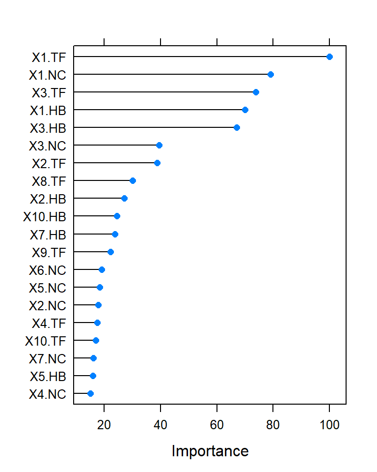

```r
 plot(rf_plot[[1]], top = 20)
```

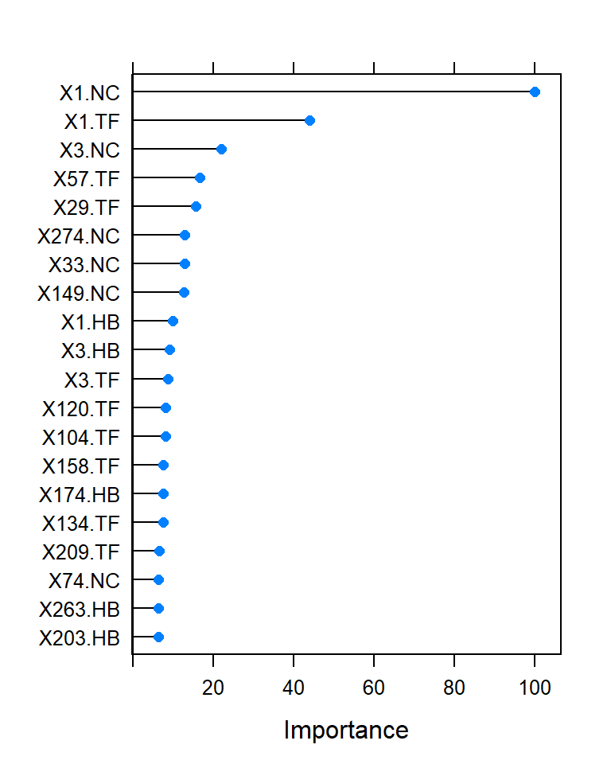

```r
 plot(rf_plot[[4]], top = 20)
```

### Gradient Boosting

Second the variable importance of the boosted trees is presented for the first and last run, such as seen in the paper.

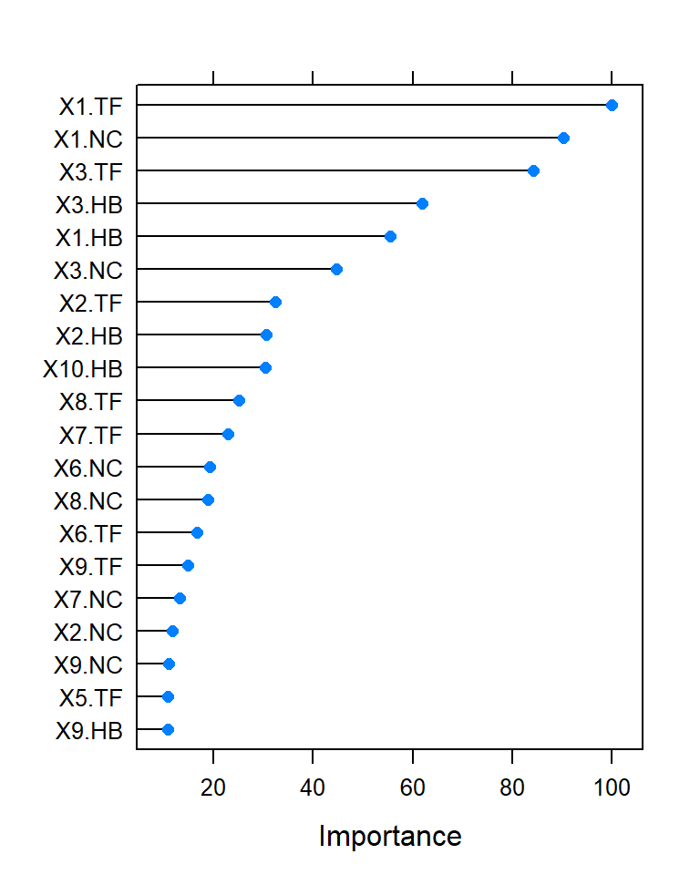

```r
 gbm_plot[[1]]
```

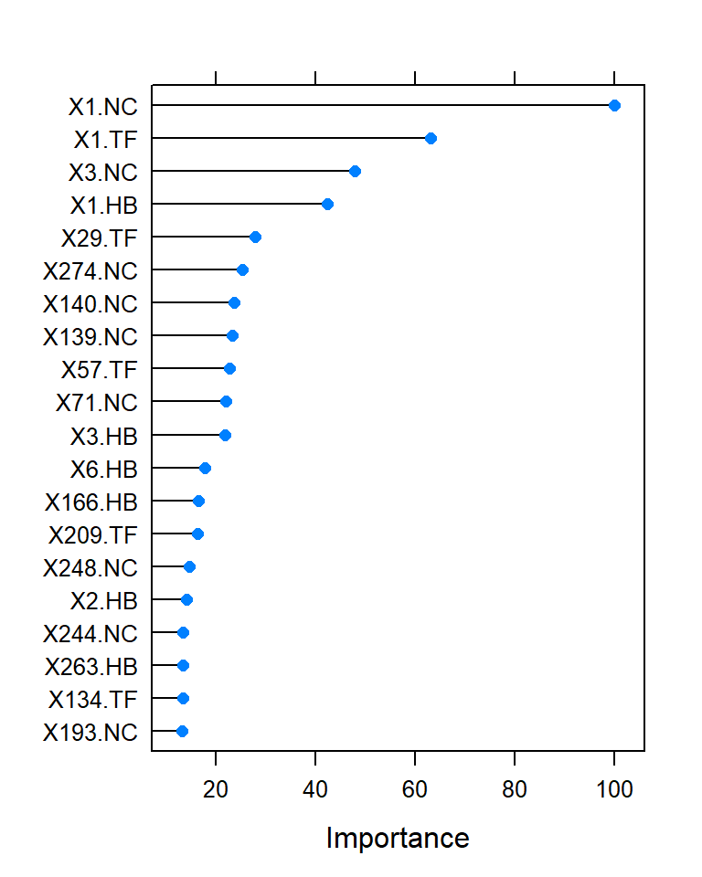

```r
 gbm_plot[[4]]
```

# Session Info and Warnings

*search()* shows the loaded packages

```r
search()
```

```
##  [1] ".GlobalEnv"           "package:xtable"       "package:stargazer"
##  [4] "package:gbm"          "package:randomForest" "package:rpart.plot"
##  [7] "package:rpart"        "package:glmnet"       "package:Matrix"
## [10] "package:caret"        "package:ggplot2"      "package:lattice"
## [13] "package:mlogit"       "package:lmtest"       "package:zoo"
## [16] "package:Formula"      "package:evd"          "package:mvtnorm"
## [19] "package:stats"        "package:graphics"     "package:grDevices"
## [22] "package:utils"        "package:datasets"     "package:methods"
## [25] "Autoloads"            "package:base"
```

The warnings have not been presented in order to save space, but could be viewed in the r-data file if interested.

```r
warnings()
```